# An examination of the cost to health and property of natural disasters

```r
knitr::opts_chunk$set(echo = TRUE)
options(scipen = 7, digits = 2)
```

## Importing the data and preparing data

First we load the relevant libraries:

```r
library(dplyr)
```

```r
library(ggplot2)
```

Then we create check if the relevant folder structure and files are downloaded, if not they will be:

```r
dataPath <- paste(getwd(), "/data/rawStormData.csv.bz2", sep = "")
if(!dir.exists("data")){
        dir.create("data")
        if(!file.exists(dataPath)){
                download.file("https://d396qusza40orc.cloudfront.net/repdata%2Fdata%2FStormData.csv.bz2", dataPath, method="curl")
        }
}else{
        if(!file.exists(dataPath)){
                 download.file("https://d396qusza40orc.cloudfront.net/repdata%2Fdata%2FStormData.csv.bz2", dataPath, method="curl")
        }
}
```

We convert the data into a dplyr compatible data frame:

```r
stormData <- tbl_df(read.csv(dataPath))
head(stormData)
```

```
## # A tibble: 6 x 37
##   STATE__           BGN_DATE BGN_TIME TIME_ZONE COUNTY COUNTYNAME  STATE
##     <dbl>             <fctr>   <fctr>    <fctr>  <dbl>     <fctr> <fctr>
## 1       1  4/18/1950 0:00:00     0130       CST     97     MOBILE     AL
## 2       1  4/18/1950 0:00:00     0145       CST      3    BALDWIN     AL
## 3       1  2/20/1951 0:00:00     1600       CST     57    FAYETTE     AL
## 4       1   6/8/1951 0:00:00     0900       CST     89    MADISON     AL
## 5       1 11/15/1951 0:00:00     1500       CST     43    CULLMAN     AL
## 6       1 11/15/1951 0:00:00     2000       CST     77 LAUDERDALE     AL
## # ... with 30 more variables: EVTYPE <fctr>, BGN_RANGE <dbl>,
## #   BGN_AZI <fctr>, BGN_LOCATI <fctr>, END_DATE <fctr>, END_TIME <fctr>,
## #   COUNTY_END <dbl>, COUNTYENDN <lgl>, END_RANGE <dbl>, END_AZI <fctr>,
## #   END_LOCATI <fctr>, LENGTH <dbl>, WIDTH <dbl>, F <int>, MAG <dbl>,
## #   FATALITIES <dbl>, INJURIES <dbl>, PROPDMG <dbl>, PROPDMGEXP <fctr>,
## #   CROPDMG <dbl>, CROPDMGEXP <fctr>, WFO <fctr>, STATEOFFIC <fctr>,
## #   ZONENAMES <fctr>, LATITUDE <dbl>, LONGITUDE <dbl>, LATITUDE_E <dbl>,
## #   LONGITUDE_ <dbl>, REMARKS <fctr>, REFNUM <dbl>
```

Converting factors to date objects and filter out all entries earlier than 1995, the cutoff point is somewhat arbitrary here but it is done because we are told that the data is less reliable for earlier entries.

```r
stormData$BGN_DATE <- as.POSIXct(stormData$BGN_DATE, format = "%m/%d/%Y %H:%M:%S")
stormData <- stormData %>%
        filter(BGN_DATE > "1995-01-01")
```

## Health related cost

First we select the relevant columns, the type of event, fatalities and injuries. I have choosen to equate fatalities with injuries, it may be more realistic to weight the two varables differently (e.g. one death may equal 5 injuries) but since this is not specified, I have simply created one category(healthcost) which is the sum of injuries and fatalities for each event.

```r
healthData <-
        select(stormData, FATALITIES, INJURIES, EVTYPE) %>%
        mutate(healthcost = FATALITIES + (INJURIES))
```

We then arrange the data by event and produce the average, sd and mean for the data. We then take the top 15 events, based on the number of absolute deaths/injuries.

```r
healthCostMean <-
        healthData %>%
        group_by(EVTYPE) %>%
        summarise(average = mean(healthcost),
                  sd = sd(healthcost, na.rm=TRUE),
                  sum = sum(healthcost)) %>%
        arrange(desc(sum))
healthCostMean <- healthCostMean[1:15,]
```

Here we produce the relevant plot for the presentation part.

```r
healthPlot <-  qplot(average, sd, size = sum, color = EVTYPE, data = healthCostMean,
                       main = "Distribution of harmful events",
                       xlab = "Mean",
                       ylab = "Standard Deviation"
                       )
```

## Economic cost

First we select the relevant columns, the type of event, property and crop damage.

```r
damageData <-
        stormData %>%
        select(PROPDMG,PROPDMGEXP, CROPDMG, CROPDMGEXP, EVTYPE) %>%
        group_by(EVTYPE)
```

```r
letterAdjuster <- function(x){
        if(x == "K"){
                x <- 1000
        }
        if(x=="M"){
                x <- 1000000

        }
        if(x=="B"){
                x <- 1000000000
        }
        else{
                x <- 1
        }
}
damageData$PROPDMGEXP <- sapply(damageData$PROPDMGEXP, letterAdjuster)
damageData$CROPDMGEXP <- sapply(damageData$CROPDMGEXP, letterAdjuster)
```

We then subset create a new column called damageValue which adds the property damage to the cropdamage, we calculate the mean, standard deviation and absolut sum of the cost. We then arrange these in the absolute cost per event type and extract the top 15 entries.

```r
unifiedDamage <-
        damageData %>%
        select(EVTYPE, PROPDMG, PROPDMGEXP, CROPDMG,CROPDMGEXP) %>%
        mutate(damageValue = (PROPDMGEXP*PROPDMG) + (CROPDMGEXP*CROPDMG)) %>%
        group_by(EVTYPE) %>%
        summarise(damageMean = mean(damageValue),
                  damageSD = sd(damageValue),
                  damageSum = sum(damageValue)) %>%
        arrange(desc(damageSum))
unifiedDamage <- unifiedDamage[1:15,]
```

Here we produce the relevant plot for the presentation.

```r
damagePlot <-  qplot(damageMean, damageSD, size = damageSum, color = EVTYPE, data = unifiedDamage,
                       xlab = "Mean",
                       ylab= "Standard Deviation",
                       main = "Mean/Sum distribution based on event types"
                       )
```

## Results

### Harm

```r
topMean <- arrange(healthCostMean, desc(average))
topMean
```

```
## # A tibble: 15 x 4
##               EVTYPE average    sd   sum
##               <fctr>   <dbl> <dbl> <dbl>
## 1  HURRICANE/TYPHOON 15.2159 90.66  1339
## 2     EXCESSIVE HEAT  5.0316 27.47  8428
## 3               HEAT  3.9126 29.86  2954
## 4                FOG  1.4561  6.20   779
## 5            TORNADO  0.9579 13.38 23310
## 6          LIGHTNING  0.3754  1.31  5360
## 7           WILDFIRE  0.3576  3.00   986
## 8              FLOOD  0.2919 11.20  7192
## 9       WINTER STORM  0.1313  2.25  1493
## 10         HIGH WIND  0.0668  0.82  1334
## 11        HEAVY SNOW  0.0588  1.16   865
## 12       FLASH FLOOD  0.0507  1.33  2668
## 13         TSTM WIND  0.0300  0.52  3871
## 14 THUNDERSTORM WIND  0.0190  0.47  1557
## 15              HAIL  0.0043  0.40   926
```

Here are the fifteen most harmful event types based on the absolute number amount harm caused:

```r
topSum <- arrange(healthCostMean, desc(sum))
topSum
```

```
## # A tibble: 15 x 4
##               EVTYPE average    sd   sum
##               <fctr>   <dbl> <dbl> <dbl>
## 1            TORNADO  0.9579 13.38 23310
## 2     EXCESSIVE HEAT  5.0316 27.47  8428
## 3              FLOOD  0.2919 11.20  7192
## 4          LIGHTNING  0.3754  1.31  5360
## 5          TSTM WIND  0.0300  0.52  3871
## 6               HEAT  3.9126 29.86  2954
## 7        FLASH FLOOD  0.0507  1.33  2668
## 8  THUNDERSTORM WIND  0.0190  0.47  1557
## 9       WINTER STORM  0.1313  2.25  1493
## 10 HURRICANE/TYPHOON 15.2159 90.66  1339
## 11         HIGH WIND  0.0668  0.82  1334
## 12          WILDFIRE  0.3576  3.00   986
## 13              HAIL  0.0043  0.40   926
## 14        HEAVY SNOW  0.0588  1.16   865
## 15               FOG  1.4561  6.20   779
```

The event type with the highest amount of harm in absolute number is clearly tornados. However they have a mean of just below 1 death or injury per occurance and standard deviation of 13. This is probably due to the fact that there are a lot of tornados and a lot of the time they may do little damage if they occur in rural areas.

The event type with the most harm in terms of a high mean is Hurrican/Typhoon, it is however also very variable with a standard deviation of about 90.

Here is a chart of the types of events, average, standard deviation, size in one plot.

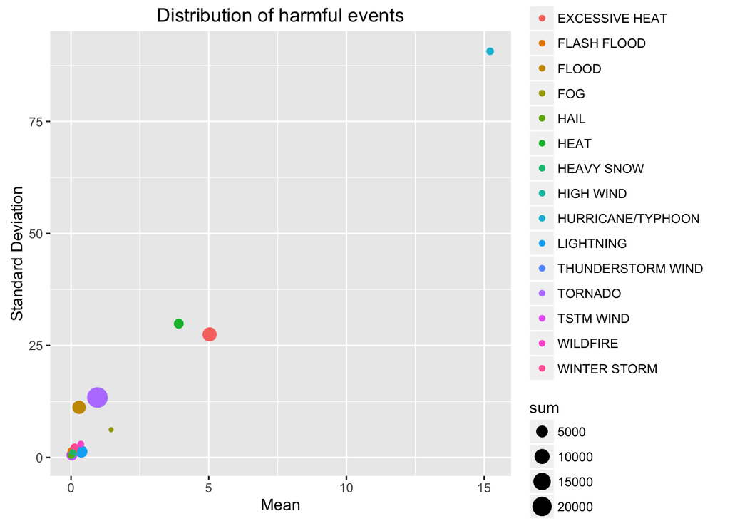

```r
healthPlot
```

This information seems to indicate that the most effective way of reducing the harm would be to focus on reducing the harm from tornados and hurricanes/typhoons, actions that adress these events would likely overlap so you could to a certain extent reduce both at the same time, if you had to choose one then it would probably be better to go for measures against tornados but the consequences could be severe if you experience a year with a lot of hurricanes/typhoons or if one hits in a densely populated area. I can imagine that an increase in hurricanes/typhoons could be a likley consequence of global warming in a lot of areas but do not have any data to prove it so it is only to be considered an untested hypothesis at this point.

### Economic cost

Here is the economic cost in the absolute value:

```r
unifiedDamage
```

```
## # A tibble: 15 x 4
##                       EVTYPE damageMean   damageSD    damageSum
##                       <fctr>      <dbl>      <dbl>        <dbl>
## 1                      FLOOD    4971429  733050938 122500992223
## 2          HURRICANE/TYPHOON  761477393 2497829626  67010010571
## 3                STORM SURGE  168221420 2088629547  42560019226
## 4                  HURRICANE   33529528  274119192   5700019792
## 5                    TORNADO     217848   21346978   5301330183
## 6             TROPICAL STORM    7529318  196915169   5150053203
## 7           STORM SURGE/TIDE   27027079  328797970   4000007623
## 8             HURRICANE OPAL  344444549  736734484   3100000937
## 9  HEAVY RAIN/SEVERE WEATHER 1250000000 1767766953   2500000000
## 10                      HAIL       8341    3873593   1801112858
## 11          WILD/FOREST FIRE    1037374   39446375   1500043522
## 12                   DROUGHT     607303   22492418   1500037446
## 13                 HIGH WIND      65160    9202516   1300332816
## 14       SEVERE THUNDERSTORM  109090937  361813604   1200000310
## 15                  WILDFIRE     377253   19806829   1040087768
```

Here is the economic cost ranked by the mean value:

```r
unifiedDamageMean <- unifiedDamage %>% arrange(desc(damageMean))
unifiedDamageMean
```

```
## # A tibble: 15 x 4
##                       EVTYPE damageMean   damageSD    damageSum
##                       <fctr>      <dbl>      <dbl>        <dbl>
## 1  HEAVY RAIN/SEVERE WEATHER 1250000000 1767766953   2500000000
## 2          HURRICANE/TYPHOON  761477393 2497829626  67010010571
## 3             HURRICANE OPAL  344444549  736734484   3100000937
## 4                STORM SURGE  168221420 2088629547  42560019226
## 5        SEVERE THUNDERSTORM  109090937  361813604   1200000310
## 6                  HURRICANE   33529528  274119192   5700019792
## 7           STORM SURGE/TIDE   27027079  328797970   4000007623
## 8             TROPICAL STORM    7529318  196915169   5150053203
## 9                      FLOOD    4971429  733050938 122500992223
## 10          WILD/FOREST FIRE    1037374   39446375   1500043522
## 11                   DROUGHT     607303   22492418   1500037446
## 12                  WILDFIRE     377253   19806829   1040087768
## 13                   TORNADO     217848   21346978   5301330183
## 14                 HIGH WIND      65160    9202516   1300332816
## 15                      HAIL       8341    3873593   1801112858
```

Here is a plot similar to that used when examining the harm:

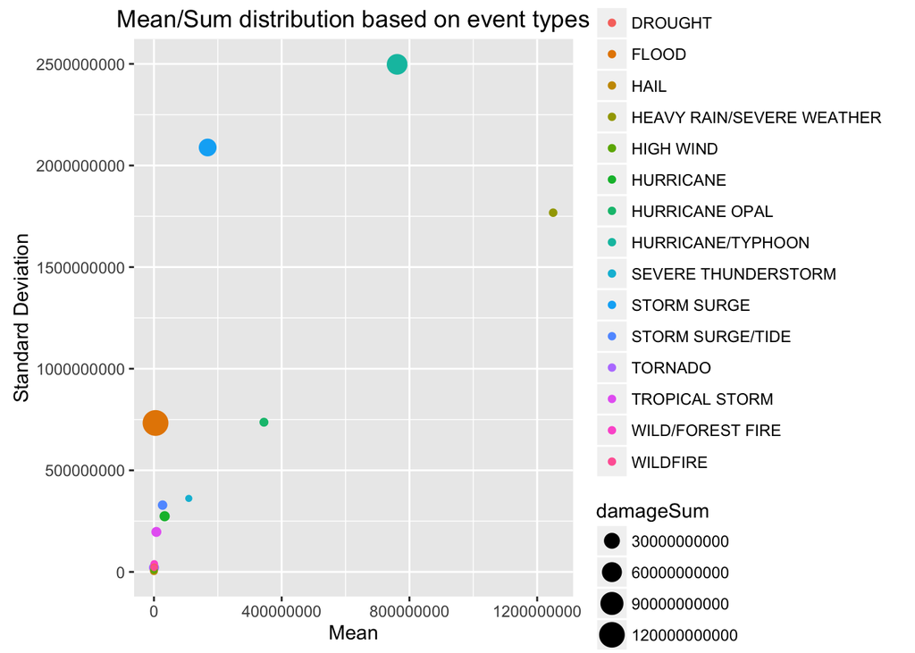

```r
damagePlot
```

Again, the results here seem to indicate that any measures taken to prevent damage in cases of hurricanes/typhoons, tornados, storms etc. I would argue that these measures would be the best to implement because any action taken to reduce the economic cost of a hurricane will also be effective against a storm, tornado, tropical storm etc.

A key thing here is to consider flooding as well as storm surges, these are also likely related to the measures taken against the weather related events mentioned in the preceding paragraph.